# 1. Source code

Let's start with all the source code first!

The output will be shown below.

## a) Cartesian Product

This function generates all possible combinations of results when rolling multiple dice. It uses recursion to accumulate the results from each roll.

```python
def cartesian(die, number_dice=1, acc_func=lambda x, y: x + y):
    """
    :param die: list of possible values of one die roll
    :param number_dice: how many dice to be used
    :param acc_func: function for accumulating the values from both dice
    :return: list of all possible combinations of results for the dice roll
    """
    if number_dice < 1:
        return []

    if number_dice == 1:
        return die

    accumulated = []
    for x in cartesian(die, number_dice - 1, acc_func):
        for y in die:
            accumulated.append(acc_func(x, y))

    return accumulated
```

## b) Advantage

In the context of Dungeons & Dragons, this function calculates the outcomes when rolling with advantage, meaning two dice are rolled and the higher result is used.

```python
def advantage(die, number_dice):
    return cartesian(cartesian(die, number_dice), 2, max)
```

## c) Run calculations

This function computes the probabilities of each possible outcome for a given number of dice, using the specified rolling function.

```python
def calc(die, number_dice=1, roll_func=lambda d, n: cartesian(d, n)):
    """
    :param die: list of possible values of one die roll
    :param number_dice: how many dice to be used
    :param roll_func: function for determining all possible combinations
    :return: a dictionary with distinct results and their probability of occurrence
    """
    def group_numbers(unordered):
        grouped = {}
        for x in unordered:
            if x in grouped.keys():
                grouped[x] = grouped[x] + 1
            else:
                grouped[x] = 1

        return grouped

    def odds(grouped):
        total = sum(grouped.values())

        result = {}
        for k in grouped.keys():
            result[k] = (grouped[k] / total) * 100

        return result

    return odds( group_numbers( roll_func(die, number_dice) ) )
```

## d) Plotting the results

This function plots the calculated probabilities, comparing the outcomes of normal rolls to those with advantage, for easy visual comparison.

```python
import matplotlib.pyplot as plt

def plot_data_adv(data_normal, data_adv, title):
    """
    :param data_normal: dictionary to be plotted
    :param data_adv: same count of dice, just with advantage
    :param title: individual title for the diagram
    """
    plt.title(title)
    plt.xlabel("Roll")
    plt.ylabel("Odds in %")
    plt.plot(data_normal.keys(), data_normal.values(), color="b", label='normal')
    plt.plot(data_adv.keys(), data_adv.values(), color="r", label='advantage')
    plt.legend()
    plt.show()
```

## e) Print table

This function prints a formatted table displaying the odds of each possible result for normal rolls and rolls with advantage.

```python
def printTable(normal, adv):
    print("| {:<6} | {:<10} | {:<12} |".format('Result', 'Normal (%)', 'Advanced (%)'))
    print("++++++++++++++++++++++++++++++++++++++++")

    for key, value in normal.items():
        print("| {:<6} | {:<10} | {:<12} |".format(key, round(value, 4), round(adv[key], 4)))
```

## f) Die definition

Defines the die used in the calculations, typically a six-sided die (1-6).

```python
die = range(1, 7)
```

# 2. Results

Now, here is the output of the source code above!

## a) One die

Calculates and plots the probabilities for rolling one die, both normally and with advantage, and prints the results in a table.

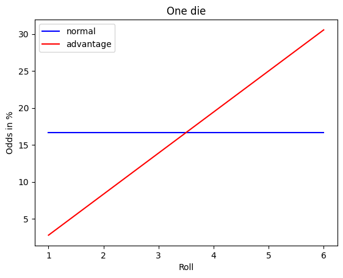

```
| Result | Normal (%) | Advanced (%) |
++++++++++++++++++++++++++++++++++++++++
| 1      | 16.6667    | 2.7778       |
| 2      | 16.6667    | 8.3333       |
| 3      | 16.6667    | 13.8889      |
| 4      | 16.6667    | 19.4444      |
| 5      | 16.6667    | 25.0         |
| 6      | 16.6667    | 30.5556      |
```

```python
normal = calc(die)
adv = calc(die, roll_func=advantage)

plot_data_adv(normal, adv,"One die")
printTable(normal, adv)
```

## b) Two dice

Calculates and plots the probabilities for rolling two dice, both normally and with advantage, and prints the results in a table.

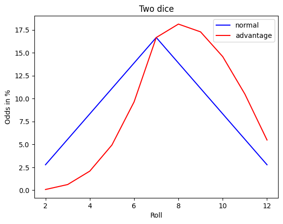

```
| Result | Normal (%) | Advanced (%) |
++++++++++++++++++++++++++++++++++++++++
| 2      | 2.7778     | 0.0772       |
| 3      | 5.5556     | 0.6173       |
| 4      | 8.3333     | 2.0833       |
| 5      | 11.1111    | 4.9383       |
| 6      | 13.8889    | 9.6451       |
| 7      | 16.6667    | 16.6667      |
| 8      | 13.8889    | 18.1327      |
| 9      | 11.1111    | 17.284       |
| 10     | 8.3333     | 14.5833      |
| 11     | 5.5556     | 10.4938      |
| 12     | 2.7778     | 5.4784       |
```

```python
normal_2 = calc(die, 2)
adv_2 = calc(die, 2, advantage)

plot_data_adv(normal_2, adv_2,"Two dice")
printTable(normal_2, adv_2)
```

## c) Four dice

Calculates and plots the probabilities for rolling four dice, both normally and with advantage, and prints the results in a table.

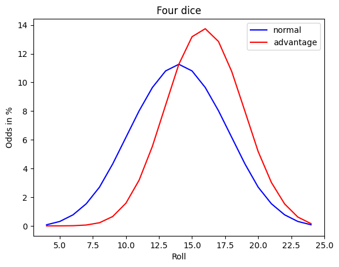

```
| Result | Normal (%) | Advanced (%) |
++++++++++++++++++++++++++++++++++++++++
| 4      | 0.0772     | 0.0001       |
| 5      | 0.3086     | 0.0014       |
| 6      | 0.7716     | 0.0119       |
| 7      | 1.5432     | 0.0595       |
| 8      | 2.7006     | 0.2188       |
| 9      | 4.321      | 0.6535       |
| 10     | 6.1728     | 1.5813       |
| 11     | 8.0247     | 3.195        |
| 12     | 9.6451     | 5.5444       |
| 13     | 10.8025    | 8.4186       |
| 14     | 11.2654    | 11.2654      |
| 15     | 10.8025    | 13.1863      |
| 16     | 9.6451     | 13.7457      |
| 17     | 8.0247     | 12.8544      |
| 18     | 6.1728     | 10.7644      |
| 19     | 4.321      | 7.9885       |
| 20     | 2.7006     | 5.1824       |
| 21     | 1.5432     | 3.0269       |
| 22     | 0.7716     | 1.5313       |
| 23     | 0.3086     | 0.6159       |
| 24     | 0.0772     | 0.1543       |
```

```python
normal_4 = calc(die, 4)
adv_4 = calc(die, 4, advantage)

plot_data_adv(normal_4, adv_4, "Four dice")
printTable(normal_4, adv_4)
```